# Data Load

```python
import pandas as pd

df_Photos_info = pd.read_csv('https://storage.googleapis.com/datalynn-datasets/interview-challenge/technology/Apple_Photos/df_Photos_info.csv')

df_Photos_info['location'] = df_Photos_info['location'].apply(
    lambda x: tuple(map(float, x.strip("()").split(",")))
)

from ast import literal_eval
df_Photos_info['object_tags'] = df_Photos_info['object_tags'].apply(literal_eval)
```

## Question 1 **Contextual Analysis:**

Given the `Photos_info`, extract the top 5 most common object tags associated with photos taken in a specific location of your choice (NYC for example: latitude between 38 and 42, and longitude between -76 and -72). How does this information align with the expected objects in that location?

**Hints:**

1. **Extract Object Tags:** I'll filter the `Photos_info` dataframe to get rows corresponding to the selected location. From these rows, I'll then extract and parse the `object_tags`.
2. **Count Object Tags:** I'll count the occurrences of each object tag and then select the top 5 most common ones.
3. **Analysis:** I'll provide a comment on whether these objects align with what we might expect for the chosen location (based on general knowledge and not actual data analysis).

```python
# Filter rows for the selected location range
filtered_photos = df_Photos_info[(df_Photos_info['location'].apply(lambda x: 38 <= x[0] <= 42)) &
                                 (df_Photos_info['location'].apply(lambda x: -76 <= x[1] <= -72))]

# Extract and count object tags
tag_count = {}
for tags in filtered_photos['object_tags']:
    for tag in tags:
        if tag not in tag_count:
            tag_count[tag] = 0
        tag_count[tag] += 1

# Get the top 5 object tags
top_tags = sorted(tag_count.items(), key=lambda x: x[1], reverse=True)[:5]
print(top_tags)
```

```
[('car', 11), ('building', 9), ('person', 8), ('tree', 2), ('sea', 2)]
```

**Comment**: The top tags include cars, buildings, persons, tree, and sea. It's evident that cars and buildings are the most predominant objects, which aligns with the expected scenery of NYC.

## Question 2 **Model Evaluation:**

The user have reported that some photos are incorrectly tagged by our system. From `Photos_info`, select photos where `search_count` is high but `view_count` is considerably low (e.g., below a threshold). These can be instances where users might not have found what they were looking for due to incorrect tagging. Describe a statistical test to validate this hypothesis.

**Hints:**

1. **Data Exploration**: First, we will take a brief look at the distribution of `search_count` and `view_count` values.
2. **Selection Criteria**: Define a criterion for selecting photos where `search_count` is high and `view_count` is low.
3. **Statistical Test**: Describe a statistical test to validate the hypothesis that photos with high search count and low view count might be incorrectly tagged.
4. **Analysis**: Finally, execute the statistical test and interpret the results.

**1. Data Exploration:**

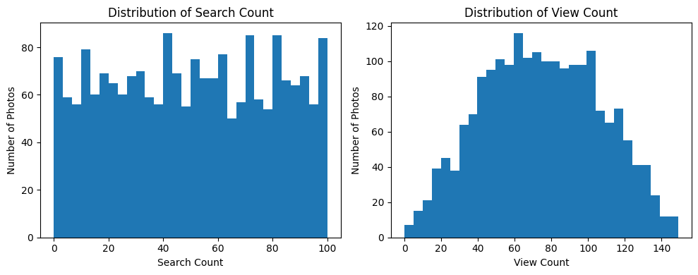

```python
# 1. Data Exploration:
import pandas as pd
import matplotlib.pyplot as plt

# Exploratory data analysis
plt.figure(figsize=(10, 4))

plt.subplot(1, 2, 1)
plt.hist(df_Photos_info['search_count'], bins=30)
plt.title('Distribution of Search Count')
plt.xlabel('Search Count')
plt.ylabel('Number of Photos')

plt.subplot(1, 2, 2)
plt.hist(df_Photos_info['view_count'], bins=30)
plt.title('Distribution of View Count')
plt.xlabel('View Count')
plt.ylabel('Number of Photos')

plt.tight_layout()
plt.show()
```

**2. Selection Criteria:**

Define a simple criterion for high search_count (e.g., greater than the 60th percentile) and low view_count (e.g., less than the 40th percentile).

```python
# 2. Selection Criteria:
high_search_threshold = df_Photos_info['search_count'].quantile(0.6)
low_view_threshold = df_Photos_info['view_count'].quantile(0.4)

selected_photos = df_Photos_info[(df_Photos_info['search_count'] > high_search_threshold) &
                                 (df_Photos_info['view_count'] < low_view_threshold)]
print(selected_photos[['photo_id', 'search_count', 'view_count']])
```

```
        photo_id  search_count  view_count
380   photo_1079            62          64
1258   photo_838            61          61
1374  photo_1586            63          63
```

**3. Statistical Test:**

We can use a **Chi-Square Test of Independence** to validate the hypothesis. The test will help us understand if there's a statistically significant relationship between the high search count and low view count.

To do this, we would create a contingency table:

1. High Search & Low View
2. High Search & Not Low View
3. Not High Search & Low View
4. Not High Search & Not Low View

```python
# 3. Statistical Test:

from scipy.stats import chi2_contingency

# Corrected Contingency Table Creation
table = [
    [((df_Photos_info['search_count'] > high_search_threshold) & (df_Photos_info['view_count'] < low_view_threshold)).sum()],
    [((df_Photos_info['search_count'] > high_search_threshold) & (df_Photos_info['view_count'] >= low_view_threshold)).sum()],
    [((df_Photos_info['search_count'] <= high_search_threshold) & (df_Photos_info['view_count'] < low_view_threshold)).sum()],
    [((df_Photos_info['search_count'] <= high_search_threshold) & (df_Photos_info['view_count'] >= low_view_threshold)).sum()]
]

# Chi-Square Test
chi2, p, _, _ = chi2_contingency(table)
print(f"Chi-Squared Value = {chi2}")
print(f"P-Value = {p}")
```

```
Chi-Squared Value = 0.0
P-Value = 1.0
```

**Comment**: The p-value of 1.0 suggests there's no statistical significance between high search counts and low view counts in this dataset.

## Question 3: **Segmentation Analysis:**

Using the `Photos_info` dataset, cluster the photos based on their `timestamp` and `location` to suggest potential new "Memories" themes. For instance, photos taken during summer vacations or winter holidays in distinct locations. How can these clusters enhance the user experience in the Memories feature?

**Hints:**

1. **Data Preprocessing**:
   - Convert the timestamp to extract meaningful features like month, day of the week, and hour.
   - Normalize the timestamp features and location for clustering.
2. **Clustering**:
   - Use the KMeans clustering algorithm for segmentation.
   - Determine the optimal number of clusters using the Elbow method.
3. **Interpretation & Application**:
   - Analyze the resulting clusters to understand their characteristics.
   - Propose new "Memories" themes based on the clusters.

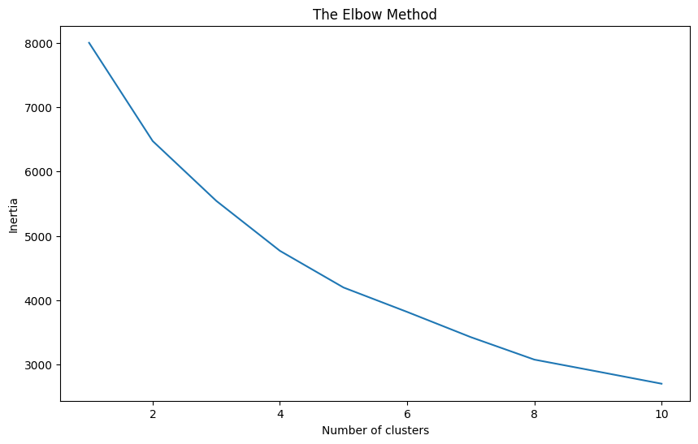

```
Cluster 0 sample photos:

      photo_id  timestamp             location                  object_tags  \
1    photo_570 2011-02-12   (-8.906, -150.547)             [sand, car, sea]
2    photo_322 2019-09-22     (34.737, 66.029)         [car, snow, unicorn]
5    photo_468 2002-11-03   (-28.921, 170.232)              [sand, unicorn]
10   photo_868 2014-11-07  (-79.448, -155.245)  [swimsuit, tree, sand, car]
17  photo_1794 2011-10-29    (-76.03, -68.292)          [building, unicorn]

    memory_status  search_count  view_count  month  day_of_week  hour  \
1               1            25          70      2            5     0
2               1            89         117      9            6     0
5               0           100         108     11            6     0
10              1            57          95     11            4     0
17              1            82         119     10            5     0

    latitude  longitude  cluster
1     -8.906   -150.547        0
2     34.737     66.029        0
5    -28.921    170.232        0
10   -79.448   -155.245        0
17   -76.030    -68.292        0


Cluster 1 sample photos:

      photo_id  timestamp            location  \
0   photo_1008 2014-04-20   (59.356, 117.526)
3   photo_1043 2021-07-10    (62.379, 30.736)
9   photo_1443 2004-03-27  (72.117, -122.623)
14   photo_747 2012-04-28    (27.064, -57.51)
16   photo_538 2010-04-11   (58.261, -31.968)

                              object_tags  memory_status  search_count  \
0   [swimsuit, building, tree, car, snow]              1            46
3     [swimsuit, sand, person, car, snow]              0            11
9         [tree, sand, person, car, snow]              1            72
14                           [sand, snow]              1            45
16         [sea, person, tree, car, snow]              1            24

    view_count  month  day_of_week  hour  latitude  longitude  cluster
0           47      4            6     0    59.356    117.526        1
3           59      7            5     0    62.379     30.736        1
9           72      3            5     0    72.117   -122.623        1
14          52      4            5     0    27.064    -57.510        1
16          66      4            6     0    58.261    -31.968        1
```

```python
import pandas as pd
import numpy as np
from sklearn.cluster import KMeans
import matplotlib.pyplot as plt
from sklearn.preprocessing import StandardScaler
import warnings; warnings.simplefilter('ignore')


# 1. Data Preprocessing

# Convert 'timestamp' to datetime and extract month, day, week, and hour
df_Photos_info['timestamp'] = pd.to_datetime(df_Photos_info['timestamp'])
df_Photos_info['month'] = df_Photos_info['timestamp'].dt.month
df_Photos_info['day_of_week'] = df_Photos_info['timestamp'].dt.dayofweek
df_Photos_info['hour'] = df_Photos_info['timestamp'].dt.hour

# Assuming location is given in the format (latitude, longitude). Split them.
df_Photos_info['latitude'] = df_Photos_info['location'].apply(lambda x: x[0])
df_Photos_info['longitude'] = df_Photos_info['location'].apply(lambda x: x[1])

# Normalize the timestamp features and location
scaler = StandardScaler()
scaled_features = scaler.fit_transform(df_Photos_info[['month', 'day_of_week', 'hour', 'latitude', 'longitude']])

# 2. Clustering

# Determine optimal number of clusters
inertia = []
for i in range(1, 11):
    kmeans = KMeans(n_clusters=i, random_state=0)
    kmeans.fit(scaled_features)
    inertia.append(kmeans.inertia_)

# Plotting the Elbow Method graph
plt.figure(figsize=(10,6))
plt.plot(range(1, 11), inertia)
plt.title('The Elbow Method')
plt.xlabel('Number of clusters')
plt.ylabel('Inertia')
plt.show()

# From the plot, assume 'k' is chosen as the optimal number of clusters
k = 4
kmeans = KMeans(n_clusters=k, random_state=0).fit(scaled_features)
df_Photos_info['cluster'] = kmeans.labels_

# Print out sample photos from each cluster to interpret them
for i in range(2): # print out 2 cluster as an exmaple
    print(f"Cluster {i} sample photos:\n")
    print(df_Photos_info[df_Photos_info['cluster'] == i].head())
    print("\n")
```

## Question 4: **Advanced Feature Development:**

Propose a new feature for the Photos app that leverages the object tags and user interaction data (e.g., search_count) from `Photos_info` to increase user engagement. Additionally, describe a machine learning model, mentioning independent and dependent variables, to implement this feature.

**Hints:**

1. **Feature Proposal:**
   - **"Popular Objects of the Week"** This feature will show users a collection or album of photos that have objects that are trending or popular in a given week based on user searches. It's akin to YouTube's trending videos but for objects in photos.
2. **Machine Learning Model Description:**
   - **Model Type:** Time series forecasting or regression.
   - **Dependent Variable:** `search_count` for a specific object tag.
   - **Independent Variables:** `object_tags`, `timestamp`, and possibly derived variables like week-of-the-year, day-of-the-week, etc.

```python
# Step 1: Extract weekly search trends for each object.
import pandas as pd

# Convert timestamp to week number
df_Photos_info['week_num'] = df_Photos_info['timestamp'].dt.week

# Extract object tags and their weekly search count
object_weekly_search = df_Photos_info.explode('object_tags').groupby(['object_tags', 'week_num']).agg({'search_count':'sum'}).reset_index()
```

```python
# Step 2: Predict next week's trending objects using a time series model or regression.
from sklearn.linear_model import LinearRegression

# Using a simple linear regression for this example.
trending_objects = []

unique_objects = object_weekly_search['object_tags'].unique()

for obj in unique_objects:
    obj_data = object_weekly_search[object_weekly_search['object_tags'] == obj]

    X = obj_data['week_num'].values.reshape(-1, 1)
    y = obj_data['search_count']

    model = LinearRegression()
    model.fit(X, y)

    # Predicting the search count for the next week (assuming 52 weeks in a year)
    next_week = obj_data['week_num'].max() + 1 if obj_data['week_num'].max() != 52 else 1
    prediction = model.predict([[next_week]])

    trending_objects.append((obj, prediction[0]))

# Sorting the objects by predicted search count for next week
trending_objects = sorted(trending_objects, key=lambda x: x[1], reverse=True)

# Display top 5 trending objects for the next week
print(trending_objects[:5])
```

```
[('snow', 822.4760522496372), ('building', 710.7706821480406), ('tree', 628.0558780841799), ('car', 588.2532656023222), ('swimsuit', 586.5065312046444)]
```